# A8-Metrop

John Smith

2020-03-27

# Notes

- **This document is intended to help you use Metropolis**, not the Gibbs sampler.
- A lot of explanatory material has been added, including an Appendix that reviews the product rule and the concept of independence.
- I am sending you the html, so you can see what your completed assignment might look like when you knit it. I set `echo=TRUE` in some of the chunks so you can see how plots were made and so forth, but the key chunks you will need to write yourself.
- I did a lot of experimenting with the synthetic data, so the data you see in this version might be different from the data in the earlier version. Use whichever data set you wish. The important thing is that you understand how the synthetic data is made, so that chunk is echoed below.
- The target “due date” for A8 has been extended to March 27. However, this is an important assignment that I would like everyone to complete, so I will help you individually as needed until you are able to complete it satisfactorily, irrespective of date. Send me what you have on March 27 and I will look at it over the weekend and make suggestions.

# Introduction

This assignment treats *robust* linear regression with *errors in variables*, a problem that is common in science and does not involve coins. Robustness and errors-in-variables are difficult for conventional methods, but easy for Bayesian methods. **Your assignment is** to code **either** Metropolis **or** the Gibbs sampler, then analyze the data with your code. I recommend you use Metropolis. If you aren’t sure how to code it, read Chapter 7 again, then look at the solution to Exercise 7.4 of the previous assignment.

This assignment is relevant to Chao’s research, in which pressure, density and seismic soundspeeds are measured in diamond anvil cells and then extrapolated to great depth in the earth using the second order [Birch-Murnaghan equation of state](https://en.wikipedia.org/wiki/Birch%E2%80%93Murnaghan_equation_of_state). The outstanding question is whether such extrapolations agree with the PREM model for soundspeeds and density.

It is also relevant to Andrew’s research, in which estimates of seamount age and location in various island chains are used to estimate the absolute motion of the [Pacific plate](https://en.wikipedia.org/wiki/Plate_tectonics).

In the following I often mix code-type notation with math notation, in order to remind you of distribution names and suggest names for variables in your codes. Beware that on some screens it is easy to mistake the tilde `~` for a minus sign. The tilde is how mathematicians, as well as the MCMC languages BUGS, [JAGS](https://en.wikipedia.org/wiki/Just_another_Gibbs_sampler) and Stan, indicate that the variable on the left is a sample from the distribution on the right.

**We have data** `xo[i]`, `yo[i]`, `i=1:N`. The lower case “o” in these names is a reminder that these are *observed* values, not the true values, `x[i], y[i]`, which are unknown because our measurement systems are imperfect. In the narrative I may use $x_o$ to mean the vector $(x^{(o)}_1, x^{(o)}_2, \ldots, x^{(o)}_N)$.

Our **process model** is the usual `y[i] = a*x[i] + b`. Notice that it involves the unknown true values of `x`, not the observed values `xo`. The slope `a` and intercept `b` are the only two parameters of our process model. It would be easy to have a more complicated process model with more parameters, but the process model is not our focus here. Our complete MCMC model includes the unknown x-values as variables/parameters.

Our **x-observations** come from a device that we believe has a normal distribution of errors, so our observation model for the x-values is `xo[i] ~ dnorm(mean=x[i], sd=sx)`. In mathematical notation that would be $x^{(o)}_i \sim N(x_i,\sigma_x^2)$. In other words the observation `xo[i]` is assumed to be a draw from a normal distribution with mean `x[i]` and standard deviation `sx`. In statistics, the notation $s_x$ would be reserved for sample SD, and population or distribution SD would be denoted by $\sigma_x$. I am too lazy to type `sigma_x` everywhere in my code, so I using `sx`.

We suspect that some of our **y-observations** are *outliers*, hence our observation model for the y-values is a Student t-distribution `yo[i] ~ dt(mean=y[i], df=nu, sd=sy)` in which `nu` is the *normality*, more often referred to as the *degrees of freedom*. We use the t-distribution instead of the normal because it is [fat-tailed](https://en.wikipedia.org/wiki/Fat-tailed_distribution) compared to the normal and thus more tolerant of outliers. The [double-exponential (Laplace)](https://en.wikipedia.org/wiki/Laplace_distribution) is another JAGS-supplied distribution with fat tails that you may find useful someday.

Kruschke (Section 16.2, page 458) gives a nice explanation of the t-distribution, noting that $\nu$ (Greek nu) cannot be less than 1 and that the t-distribution becomes the normal distribution in the limit as $\nu\rightarrow \infty$. Please read the entry for the Student t-distribution on page 48 of the [JAGS 4.3.0 User Manual](https://sourceforge.net/projects/mcmc-jags/files/Manuals/4.x/), noting that *k* is used there instead of $nu$ to denote the normality parameter.

# 1 JAGS

We are going to write our own MCMC code for this problem, but writing a JAGS model first may help to clarify our thinking, as well as making us appreciate the simplicity of JAGS. Some things to note about the JAGS language: (1) JAGS uses C-style commenting, in which comments have the form `/* comment */`. (2) JAGS is a [declarative language](https://en.wikipedia.org/wiki/Declarative_programming) so the order of the statements in a JAGS model does not matter. (Statement order *does* matter in Stan.) (3) JAGS parameterizes the normal and t-distributions using precision $\tau=1/\sigma^2$ instead of standard deviation. Here is the model in exactly the form we would give to JAGS:

```
model {
  for (i in 1:N) { /* observe x's and y's */
    xo[i] ~ dnorm(x[i], 1/(sx*sx))
    yo[i] ~ dt(y[i], 1/(sy*sy), nu)
  }

  for (i in 1:N) { /* deterministic process model */
    y[i] <- a*x[i] + b
  }

  for (i in 1:N) { /* priors for x's */
    x[i] ~ dunif(-10, 20)
  }

  /* more priors */
  a    ~ dunif(-10, 10)
  b    ~ dunif(-10, 10)
  lnsx ~ dunif( -5,  5)
  lnsy ~ dunif( -5,  5)

  /* more deterministic variables */
  sx  <- exp(lnsx)
  sy  <- exp(lnsy)
}
```

For clarity I wrote the JAGS model using three loops instead of one. This does not cause a loss of efficiency because JAGS doesn’t *execute* the statements in the model; rather it uses them to build a [Bayesian network](https://en.wikipedia.org/wiki/Bayesian_network), sometimes known as a *probabilistic directed acyclic graph* (DAG). Our textbook has many DAG diagrams: for example, Figure 9.7 on page 236 and Figure 17.2 on page 480. A DAG diagram is always helpful, but for non-hierarchical problems like this one I find that if I carefully scrutinize my JAGS model, I do not need to sketch the DAG for it first.

Notice in the JAGS model that I used uniform priors for the x’s, the slope, and the intercept. If I had prior information that the slope was positive I would have used the reciprocal prior. I do *not* specify priors for the unknown y’s because they are determined by the x’s, slope and intercept. By using uniform priors for $\ln(s_x)$ and $\ln(s_y)$ I effectively get exact reciprocal priors for $s_x$ and $s_y$. Kruschke would have used `dgamma(0.001, 0.001)` as the prior for $s_x$ and $s_y$, and the interval-scale variables $\ln\sigma_x$ and $\ln\sigma_y$ would not be present in his analysis.

Notice also in the JAGS model that the normality $\nu$ is a fixed parameter. In your analysis I suggest you fix it at 2. The normality parameter is difficult to resolve unless one has a lot of data because it (jargon alert) *trades off* with $\sigma_y$. Making $\nu$ smaller gives the t-distribution longer tails, but making $\sigma_y$ larger also gives it longer tails.

Our textbook does robust linear regression in Section 17.2 (page 479), but it assumes known values of $x$, and it treats the normality $\nu$ and precision $1/\sigma_y^2$ as parameters.

# 2 Synthetic data

Before trying any new code on real data one should always try it first on synthetic data, or simulated data as it is called in the social and life sciences. In the following chunk I synthesize a data set with outliers in the y-observations. The plot shows the fit of the data with `lm()`, which is a least-squares fit. `lm()` assumes that the x’s are exactly known and that the errors in y are normally distributed.

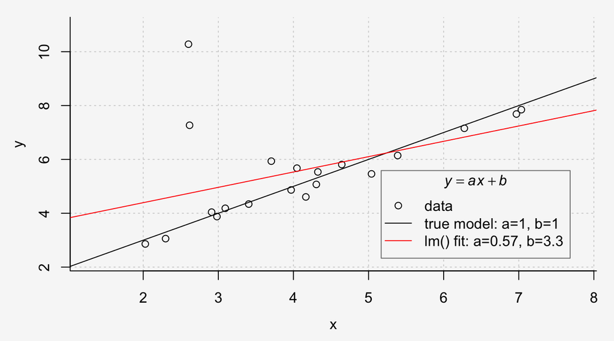

**Figure 1.** Synthetic data for a linear regression problem with y-outliers and errors in x-values. There are 20 x-y pairs in the dataset. The x-values have SD =0.2 and the y-values have SD =0.2 except that 4 of the y-values are outliers with SD =3. However, as data analysts, we cannot know which points are outliers, or even whether outliers exist in the data. All we know is that our x-meter is reliable (if not perfectly accurate) but that our y-meter has occasional glitches. Under these circumstances the best we can do is use a model that is robust to y-value outliers.

```r
par(mar=c(4, 4, 1, 1),
    mgp=c(2.5, 1, 0),
    bg="grey97")
#set.seed(seed=5, kind="Mersenne-Twister")
set.seed(seed=9, kind="Mersenne-Twister")
N <- 20     # number of data pairs
a <- 1.0    # slope
b <- 1.0    # intercept

if (c(TRUE, FALSE)[1]) { # hard test
  x  <- runif(N, min=2.0, max=7.0)
  x  <- sort(x) # x values
  sx  <- 0.2    # SDx
  sy  <- 0.2    # SDy
   r  <- 0.2    # prevalence of y-outliers
  sy1 <- 3.0    # SD for y-outliers
} else {  # easy test
  x   <- seq(from=1, to=10, length.out=N)
  sx  <- 0.1
  sy  <- 0.1    # SDy
   r  <- 0.1    # prevalence of y-outliers
  sy1 <- 0.1
}
y <- a*x + b # y values
xo <- rnorm(N, mean=x, sd=sx) # observe x's
yo <- rnorm(N, mean=y, sd=sy) # observe y's
xo <- xo[order(xo)]
yo <- yo[order(xo)]

## make y-outliers
ii <- # indices of the yo to be overwritten
  sample(1:N, size=round(r*N), replace=FALSE)
yo[ii] <- # outliers
  rnorm(length(ii), mean=y[ii], sd=sy1)

## lm() fit
fit <- lm(yo ~ xo)
alm <- coef(fit)[2]; blm <- coef(fit)[1]
## plot data, true model and lm() fit
plot(xo, yo, bty="l", panel.first=grid(),
     xlab="x", ylab="y", xaxs="i", yaxs="i",
     xlim=range(xo)+c(-1,1), ylim=range(yo)+c(-1,1))
lines(x=c(0,11), y=a*c(0,11)+b, col="black")
abline(fit, col="red")
leg2 <- paste0("true model: a=", signif(a,2), ", ",
               "b=", signif(  b,2) )
leg3 <- paste0("lm() fit: a=", signif(alm,2), ", ",
               "b=", signif(blm,2) )
legend("bottomright", bty="o", box.col="gray50",
       title=expression(italic(y==ax+b)),
       inset=c(0.05, 0.05),
       legend=c("data", leg2, leg3),
       lty=c(NA, 1, 1), pch=c(1, NA, NA),
       col=c("black", "black", "red"))
```

```r
fig.cap <- paste0("**Figure 1.** Synthetic data for a linear regression
                  problem with y-outliers and errors in x-values. ",
                  "There are ", N, " x-y pairs in the dataset. ",
                  "The x-values have SD =", sx, " and the y-values
                  have SD =", sy, " except that ", length(ii),
                  " of the y-values are outliers with SD =", sy1,
                  ". However, as data analysts, we cannot know which
                  points are outliers, or even whether outliers
                  exist in the data. All we know is that our x-meter is
                  reliable (if not perfectly accurate) but that our
                  y-meter has occasional glitches. Under these circumstances
                  the best we can do is use a model that is robust
                  to y-value outliers.")
```

**I wish I knew** why `fig.cap` gets printed after the plot; it’s very annoying. In case you have a suggestion, the only options in my chunk header are these:

```
{echo=TRUE, results="hide", fig.cap=fig.cap}
```

Outliers can wreak havoc on the least-squares model in `lm()`, and indeed you can see from the plot how two points that could be outliers have pulled the best-fit `lm()` line away from the true model. If you look in the code above you will see that there are actually 4 outliers, but only two are easily guessed at. Be aware that including the true model on the plot makes you think that you could easily guess which points are outliers, and exclude them. If I had left off the true model you would have a much more difficult time guessing, and the `lm()` fit would look quite reasonable.

# 3 Centering data

Most regression software *centers* and *scales* regression data before analyzing it, and so should yours. Why is that? Notice in Figure 1 that if the slope increases a bit the intercept will decrease a bit. The parameters $a$ and $b$ will thus be (anti) correlated and the effective sample size of your MCMC samples will be reduced. In the problem of this assignment it is sufficient to center the x-values: `xoc <- xo - mean(xo)`. To see the posterior effect of this consider our process model in the form

$$\begin{align}
y
&= a\cdot x + b \\
&= a\cdot[x_c + {\rm mean}(x^{(o)})] + b \\
&= a\cdot x_c + [b+a\cdot {\rm mean}(x^{(o)})]\\
&= a\cdot x_c + b_c
\end{align}$$

When we have finished sampling, we will have samples `a[j]` and `bc[j]` for `j=1,2,...,Ns` and the true intercept sample `b[j]` is given by `b[j] = bc[j] - a[j]*mean(xo)`.

# 4 Mathematical model

You may want to skip the math of this section on first reading, but please look at the result, equation (6*). If it doesn’t seem reasonable, go back and read the math.

I am including the deterministic variables $y$, $\sigma_x$, and $\sigma_y$ as part of the mathematical model below, because I think it is good for you to see how they are handled, and Kruschke does not cover this aspect of things.

As we intend to write our own MCMC code for this problem we now put JAGS aside and lay out the mathematical model in the canonical form $p(\beta\mid D) p(D) = p(D\mid \beta) p(\beta)$. In our application the data vector is $D=(x_o,y_o)$ and the parameter vector is $\beta=(x,y,a,b,\sigma_x,\sigma_y, e^{\ln\sigma_x}, e^{\ln \sigma_y}, \nu)$. Notice that we included *every* parameter that appeared above in the model. In order to avoid mistakes we begin as usual with a tautology for the joint distribution of parameters and data:

$$\begin{align}
\rm{LHS} &= \rm{RHS} \\
p(a,b,x,y,\sigma_x, \sigma_y, \ln\sigma_x, \ln\sigma_y, x_o, y_o \mid \nu)
&=
p(a,b,x,y,\sigma_x, \sigma_y, \ln\sigma_x, \ln\sigma_y, x_o, y_o \mid \nu),
\end{align} \tag{1}$$

in which $x, x_o, y$ and $y_o$ are all 20-element vectors. Notice that the normality $\nu$ appears to the right of the given symbol `|` because we are *specifying* $\nu$, not trying to find it from the data.

We rework the RHS by repeated use of the product rule and independence (if you aren’t entirely confident with those concepts see the appendix) obtaining

$$\begin{align}
{\rm RHS} &=
p(y_o\mid y, \sigma_y, \nu)\,p(y \mid x, a, b)\,p(\sigma_y \mid \ln\sigma_y)
\ p(\ln \sigma_y)\\
&\times
p(x_o\mid x, \sigma_x)\ p(\sigma_x \mid \ln\sigma_x) \tag{2a}
\ p(\ln \sigma_x)\\
&\times
p(x)\, p(a)\, p(b) \\ \\
&={\rm dt}(y_o\mid y, \sigma_y, \nu)\, \delta(y-ax-b)\,
\delta(\sigma_y-e^{\ln \sigma_y})
\, {\rm dunif}(\ln \sigma_y)\\
&\times {\rm dnorm}(x_0\mid x, \sigma_x)\, \delta(\sigma_x-e^{\ln \sigma_x})
\, {\rm dunif}(\ln \sigma_x) \tag{2b}\\
&\times {\rm dunif}(x)\, {\rm dunif}(a)\,
{\rm dunif}(b).
\end{align}$$

A mathematician would have written $N()$ instead of `dnorm()`, and $U()$ instead of `dunif()`, but I am mixing in coding notation as a way of thinking ahead to how the code will eventually be written.

Notice that in equation (2b) I made use of the [Dirac delta function](https://en.wikipedia.org/wiki/Dirac_delta_function) $\delta()$ to handle the deterministic variables. Paul Dirac, the physicist who was a close second to Einstein for brilliance, casually introduced his delta function in a quantum mechanics textbook, and mathematicians had their drawers in knots for a decade until they invented the theory of [generalized functions](https://en.wikipedia.org/wiki/Generalized_function) to deal with it. All we need to know is that $\delta(x-a)$ is a PDF with all of its probability mass concentrated at the single point $x=a$, and thus for any well-behaved function $f(x)$ the expectation of $f$ under the delta PDF is $E(f)=\int\! \delta(x-a)\,f(x)\,dx=f(a)$.

In our application, the process model $y=ax+b$ is assumed to be exact, hence $p(y\mid x,a,b)=\delta(y-ax-b)$, both sides being regarded as functions of $y$. Also, since $\sigma_x$ is exactly equal to $\exp(\ln x)$ it follows that $p(\sigma_x\mid \ln \sigma_x)=\delta(\sigma_x-e^{\ln x})$, and similarly for $\sigma_y$.

Integrating the RHS over the deterministic variables gives

$$\begin{align}
\small\int\! dy\ d\sigma_x \, d\sigma_y\ ({\rm RHS})
&={\rm dt}(y_o\mid a+bx, e^{\ln \sigma_y}, \nu)
\, {\rm dunif}(\ln \sigma_y)\\
&\times {\rm dnorm}(x_0\mid x, e^{\ln \sigma_x})
\, {\rm dunif}(\ln \sigma_x) \tag{3}\\
&\times {\rm dunif}(x)\, {\rm dunif}(a)\, {\rm dunif}(b).
\end{align}$$

Next we turn our attention to the left hand side of equation (1) and use the product rule to write it as a posterior distribution for the parameters times a prior predictive distribution for the data. After several applications of the product rule, and noting the independence of some variables from other variables we obtain

$$\begin{align}
\rm{LHS} &=
p(y\mid x,a,b)\, p(\sigma_x\mid\ln\sigma_x)\, p(\sigma_y\mid\ln\sigma_y)\\
&\times p(x, a, b, \ln\sigma_x, \ln\sigma_y \mid x_o, y_o, \nu) \tag{4a} \\
&\times p(x_0, y_0\mid\nu)\\
\\
&= \delta(y - ax - b)\, \delta(\sigma_x - e^{\ln\sigma_x})\,
\delta(\sigma_y - e^{\ln\sigma_y}) \\
&\times p(x, a, b, \ln\sigma_x, \ln\sigma_y \mid x_o, y_o, \nu)\tag{4b} \\
&\times p(x_0, y_0\mid\nu)
\end{align}$$

As we did above for the RHS, we integrate the LHS over the deterministic variables $y$, $\sigma_x$ and $\sigma_y$ and obtain

$$\begin{align}
\small\int\! dy\ d\sigma_x \, d\sigma_y\ ({\rm LHS})
&= p(x, a, b, \ln\sigma_x, \ln\sigma_y \mid x_o, y_o, \nu)\,
p(x_0, y_0\mid\nu). \tag{5}
\end{align}$$

Notice that each of the delta functions in the first line of (4b) integrates to 1, and there is no replacement in the second line of (4b) because neither $y$, nor $\sigma_x$, nor $\sigma_y$ is present there.

The first factor in (5) is the posterior, and the second factor, $p(x_o,y_o\mid\nu)$, is the prior predictive. Setting the integrated RHS equal to the integrated LHS and dividing by the prior predictive gets us home:

$$\begin{align}
p(x, a, b, \ln\sigma_x, \ln\sigma_y \mid x_o, y_o, \nu)
&\propto
{\rm dt}(y_o\mid a+bx, e^{\ln \sigma_y}, \nu)
\, {\rm dunif}(\ln \sigma_y)\\
&\times {\rm dnorm}(x_0\mid x, e^{\ln \sigma_x})
\, {\rm dunif}(\ln \sigma_x) \tag{6*}\\
&\times {\rm dunif}(x)\, {\rm dunif}(a)\, {\rm dunif}(b).
\end{align}$$

The derivation above was somewhat tedious because we used the variables $\ln\sigma_x$ and $\ln\sigma_y$ instead of $\sigma_x$ and $\sigma_y$, respectively. If this exercise were in our textbook the variables $\sigma_x$ and $\sigma_y$ would have been used and the final result would have been

$$\begin{align}
p(x, a, b, \sigma_x, \sigma_y \mid x_o, y_o, \nu)
&\propto
{\rm dt}(y_o\mid a+bx, \sigma_y, \nu)
\, {\rm dgamma}(\sigma_y\mid 0.001, 0.001)\\
&\times {\rm dnorm}(x_0\mid x, \sigma_x)
\, {\rm dgamma}(\sigma_x\mid 0.001,0.001) \tag{7}\\
&\times {\rm dunif}(x)\, {\rm dunif}(a)\, {\rm dunif}(b).
\end{align}$$

Recall that the gamma density with very small shape parameters is a proper approximation of the reciprocal density. The kernel of the gamma is $\sigma^{\alpha-1}e^{-\beta\sigma}$ so you can see that as $\alpha$ and $\beta$ approach zero the gamma behaves like $\sigma^{-1}$. Remember $e^0=1$.

# 5 Metropolis

Recall the Metropolis algorithm (Kruschke p. 151). We start at an arbitrary point in our 24-D space and draw a candidate point (the proposal) from a *proposal distribution* (Kruschke p. 151). We accept the proposal with probability

$$\Pr_{move}=\min\left(\frac{p(\beta_{\rm proposed}\mid D)}{p(\beta_{\rm current}\mid D)}, 1 \right)\tag{Kruschke's 7.1}$$
in which $p(\beta \mid D)$ is the posterior given by equation (6*).

The obvious choice for a proposal distribution is the multivariate normal with diagonal covariance matrix, which is a product of univariate normals. Moreover, as there is plenty of data, there is no need to make the uniform priors proper by imposing upper and lower limits, so we can replace all the instances of `dunif()` in (6) by 1, and the posterior to be evaluated becomes

$${\rm post}(x, a, b, \ln\sigma_x, \ln\sigma_y \mid x_o, y_o, \nu) =\\
\prod_{i=1}^N {\rm dt}(y^{(o)}_i \mid ax_i + b, e^{\ln\sigma_y}, \nu)
\cdot {\rm dnorm}(x^{(o)}_i \mid x_i, e^{\ln\sigma_x}) \tag{8}$$

In other words, for the proposal distribution we use a univariate normal for each element of the $N + 4$ length vector of variables $\beta=[x_1, x_2,\ldots,x_N, a, b, \ln\sigma_x, \ln\sigma_y]$. We can tune the Metropolis algorithm as needed by adjusting the standard deviations of the proposal normals.

To make this more concrete, recall that `N` is the number of x-y data pairs and suppose that sample `j` is at position

```
beta[j] = (x[j,1], x[j,2],..., x[j,N], a[j], b[j], lnsx[j], lnsy[j])
```

in our $N+4$ dimensional parameter space.

The $x_1$ element of the proposal vector is a draw  
`xp[1] ~ dnorm(mean=x[j,1], sd=sdpx)`;  
the $x_2$ element of the proposal vector is a draw  
`xp[2] ~ dnorm(mean=x[j,2], sd=sdpx)`,…;  
the $x_N$ element of the proposal vector is a draw  
`xp[N] ~ dnorm(mean=x[j,N], sd=sdpx)`;  
the $a$ element of the proposal vector is a draw  
`ap ~ dnorm(mean=a[j], sd=sdpa)`;  
the $b$ element of the proposal vector is a draw  
`bp ~ dnorm(mean=b[j], sd=sdpb)`;  
the $\ln\sigma_x$ element of the proposal vector is a draw  
`lnsxp ~ dnorm(mean=lnsx[j], sd=sdplnsx)`; and  
the $\ln\sigma_y$ element of the proposal vector is a draw  
`lnsyp ~ dnorm(mean=lnsy[j], sd=sdplnsy)`.

We can get all those draws in one call to `rnorm()` by putting the SDs into a vector:

```
SD <- c(rep(sdpx, N), sdpa, sdpb, sdplnsx, sdplnsy)
beta_prop <-rnorm(N+4, mean=beta[j], sd=SD)
```

One more thing: Notice that equation (8) is the product of many small quantities, hence numerical underflows are likely to occur. To prevent them, calculate the log-posterior first, then exponentiate it. In other words calculate your posterior as

$$\exp\sum_{i=1}^N \big[ \ln{\rm dt}(y^{(o)}_i \mid ax_i + b, e^{\ln\sigma_y}, \nu)
+ \ln{\rm dnorm}(x^{(o)}_i \mid x_i, e^{\ln\sigma_x})\big]. \tag{9}$$

Whe you call `dnorm()` set the log argument to `TRUE`. The `dt.scaled()` function in the `metRology` package has arguments analogous to those of `dnorm()`, except that there is an additional argument `df` which should be set equal to `nu`. Set `log=TRUE` in that call too. Actually there is no need to use `metRology::dt.scaled()`. A glance at its code shows that you get the same result by calling the base function `dt` like this: `dt((x-mean)/sd, df, log)/sd`. We can make our own version of this, which I will call `dts()`, as follows:

```r
dts <- function(x, mean=0, logsd=0, sd=exp(logsd), df=2, log=FALSE) {
  if(log) {
    dt((x-mean)/sd, df=df, log=TRUE) - logsd
  } else {
    dt((x-mean)/sd, df=df, log=FALSE)/sd
  }
}
```

## 5.1 Posterior

In the following chunk I create a function `posterior()` that evaluates the unscaled posterior.

```r
posterior <- function(xo,yo,x,a,b,lnsx,lnsy,nu,log=FALSE){
  ## arguments
  #  x[1:N], xo[1:N] true and observed x-values
  #  yo[1:N] observed y-values
  #  a, slope, and b, intercept (y=ax+b)
  #  lnsx, lnsy logged scale factors for sampling distributions
  #  nu, the normality
  #  log, if(log=TRUE) return log(posterior)

  N <- length(xo) # number of x-y pairs observed
  logsum <- -lnsx - lnsy +
    sum(dnorm(xo, mean=x, sd=exp(lnsx), log=TRUE) +
        dts(yo, mean=a*x+b, logsd=lnsy, df=nu, log=TRUE))

  # return posterior
  if(log) logsum else exp(logsum)
}
```

In the next chunk (not shown) I create a function to generate a proposal. You are asked to write this function yourself. By convention, function names, when they are not shorties like `f1`, should be verbs, so I gave my function the name `propose`.

Now we are ready to begin sampling.

# 6 Sampling

The first part of my sampling chunk looks like this:

```
Ns <- 5500 # number of samples, make it 1500 while debugging
nu <- 2    # normality of y-data

## preallocate storage
X <- matrix(double(Ns*N), nrow=Ns)
a <- double(Ns)
b <- double(Ns)
lnsy <- double(Ns)
lnsx <- double(Ns)
lnpost <- double(Ns) # log posterior

## center x-values
xobar <- mean(xo)
xoo <- xo         # keep original x-data
xo  <- xo - xobar # centered x-data

## initial values
X[1, ] <- xo
a[1] <- 1
b[1] <- mean(yo)
lnsx[1] <- log(0.1)
lnsy[1] <- log(0.1)
lnpost[1] <- # starting value of posterior
  posterior(xo=xo, yo=yo, x=X[1,], a=a[1], b=b[1],
            lnsx=lnsx[1], lnsy=lnsy[1], nu=nu, log=TRUE)
```

Then there is a for-loop, and the last part of my chunk looks like this:

```
## Discard first 500 samples as burn-in
burnin <- 500
a <- a[(burnin+1):Ns]
b <- b[(burnin+1):Ns]
X <- X[(burnin+1):Ns, ]
Y <- Y[(burnin+1):Ns, ]
lnsx <- lnsx[(burnin+1):Ns]
lnsy <- lnsy[(burnin+1):Ns]
lnpost <- lnpost[(burnin+1):Ns]

# estimate the MAP, the point at which the posterior is greatest
jmap <- which.max(lnpost)
amap <- a[jmap]
bmap <- b[jmap]

## Restore the x-data, for use in plotting below.
xo <- xoo
```

# 7 Metropolis results

## 7.1 Quick plots

Having calculated our samples, we plot some results.

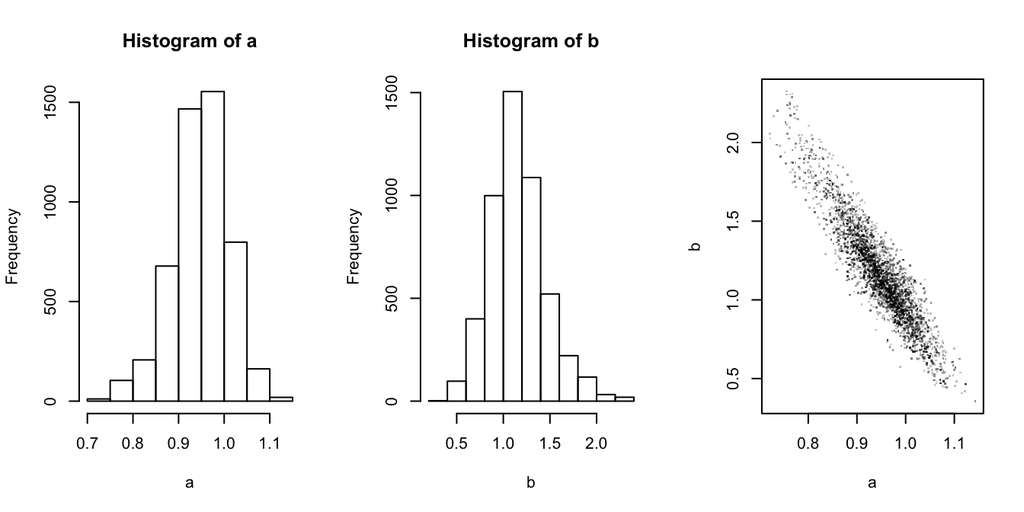

**Figure 2.** Quick plots of our results from Metropolis. Notice how short and easy is our code in the chunk that made this figure. As expected, a and b are strongly anticorrelated.

```r
par(mfcol=c(1,3))
hist(a)
hist(b)
## Reduce the opacity of "black" for plotting
## Otherwise the scatterplot is nearly solid black
myblack <- adjustcolor("black", alpha.f=0.25)
plot(a, b, pch=".", col=myblack)
```

## 7.2 Better plots

Here are basically the same plots, with improved cosmetics. One gets tired of looking at the same old black and white.

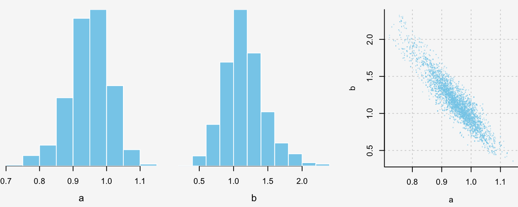

```r
par(mfcol=c(1,3),       # matrix of plots, 1 row, 3 cols
    mgp=c(2.8,1,0),     # move axis labels closer to axes
    mar=c(4.2,0,1,1),   # reduce margins 2,3,4
    bg="gray97")        # background color

hist(a, freq=FALSE,
     xlab="a", cex.lab=1.2,
     yaxs="ir", yaxt="n", ylab="", main="",
     border="white", col="skyblue")

hist(b, freq=FALSE,
     xlab="b", cex.lab=1.2,
     yaxs="ir", yaxt="n", ylab="", main="",
     border="white", col="skyblue")

par(mar=c(4.1,4.,1,0))
myblue <- adjustcolor("skyblue", alpha.f=0.50)
plot(a, b, type="p", pch=".", col=myblue,
     xlab="a", ylab="b", bty="l",
     panel.first=grid(),
     xlim=range(a), ylim=range(b))
```

# 8 The MAP

In Bayesian data analysis, the point in parameter space at which the posterior is maximum (i.e., the mode of the posterior) is called the *maximum a posteriori* point, and is referred to as the MAP. It is analogous to the *maximum likelihood estimator* (MLE) of frequentist analysis, which is the point in space at which the likelihood takes its maximum (i.e., the mode of the likelihood). We cannot find the MAP exactly, because we have only a finite number of samples, but we can estimate the MAP as the sample at which the posterior is greatest. Here we plot the `a` and `b` sample values, adding the MAP, the medians, and the `lm()` fit to the plot.

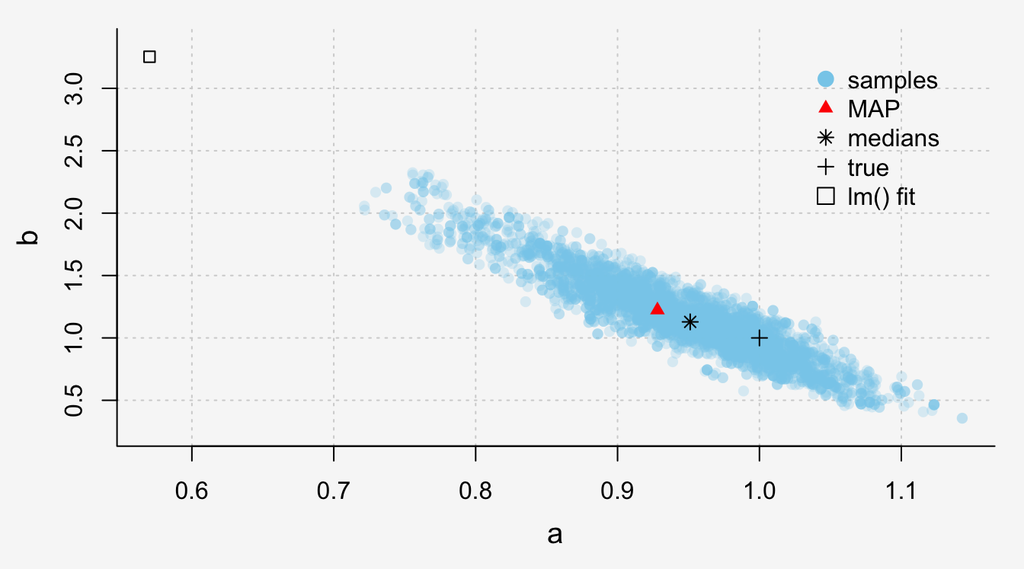

**Figure 5.** Samples from the posterior, with the MAP estimate, the medians of *a* and *b*, the best-fit *a* and *b* from lm(), way up in the upper left corner, and the true model.

```r
## scatterplot of a,b
par(mgp=c(2.5,1,0),     # move axis labels closer to axes
    mar=c(4.2,4,1,1),   # reduce margins 3,4
    bg="gray97")        # background color
myblue25 <- adjustcolor("skyblue", alpha.f=0.25)
plot(a, b, type="p", pch=16, col=myblue25,
     xlab="a", ylab="b", bty="l", cex.lab=1.2,
     panel.first=grid(),
     xlim=range(a, alm), ylim=range(b, blm)+c(-0.1, 0.1))
## add MAP to plot
points(amap, bmap, pch=17, col="red"  ) # MAP
points(1   ,    1, pch= 3, col="black") # true
points(alm ,  blm, pch= 0, col="black") # lm()
points(median(a), median(b), pch=8, col="black")

legend("topright", bty="n", inset=0.05,
       legend=c("samples", "MAP", "medians", "true", "lm() fit"),
       pch=c(16, 17, 8,  3, 0), pt.cex=c(1.5, 1, 1, 1),
       col=c("skyblue", "red", "black", "black", "black")
)
```

```r
fig.cap <- "**Figure 5.** Samples from the posterior, with the
            MAP estimate, the medians of _a_ and _b_, the
            best-fit _a_ and _b_ from lm(), way up in the upper
            left corner, and the true model."
```

# 9 Posterior checks

Some things I haven’t done yet but should do:

- Compute the effective sample size (ESS) of `a`. The ESS of `b` will naturally be much lower because it is highly correlated with `a`. Use `coda::effectiveSize(a)` to calculate the effective size of the vector of samples called `a`.
- Add the MAP estimate to our data plot and see how it compares to the true model and the fit with `lm()`.
- Make histograms of `x[1]`, `x[2]`,…, `x[N]`, `lnsy` and `lnsx` to compare with the true values and check that there is no probability mass piled up near the upper and lower limits of their respective priors; if there is, we should expand those limits and run our procedure again.
- Make scatterplots of `x[1], y[1]`, `x[2], y[2]`,…, `x[N], y[N]`, and mark the true values on those plots.
- Sample from the posterior predictive distribution as a check on our model. In other words, for each sample $\beta_j=(x_{1j}, x_{2j}, \dots, x_{Nj},a_j,b_j, \ln\sigma_x^{(j)}, \ln\sigma_y^{(j)})$ we take a draw from the sampling distribution to get predicted data points $x_{1j}^{(p)}$, $y_{1j}^{(p)}$, $x_{2j}^{(p)}$, $y_{2j}^{(p)}$, …, $x_{Nj}^{(p)}$, $y_{Nj}^{(p)}$. If the cloud of predicted data points covers most of the actual data points, our model is reasonable; if it doesn’t, we should explore other models.

Kruschke discusses posterior predictive checks on pp. 28-29, and uses them in specific cases later in the book. Formally, the posterior predictive distribution is defined by

$$p(D_p\mid D) = \int \! d\beta\, p(D_p\mid\beta)\, p(\beta\mid D)$$
in which $D_p$ is the predicted data, $p(D\mid\beta)$ is the sampling distribution, and $p(\beta\mid D)$ is the posterior. To sample from the posterior predictive we draw a sample $\beta^{(j)}$ from $p(\beta\mid D)$ and then a sample $D_p^{(j)}$ from $p(D\mid\beta^{(j)})$. In applications we already have the samples $\beta^{(j)}$ so it is easy to generate the $D_p^{(j)}$ if we wish.

Notation: If you want to emphasize that a draw $\beta^{(j)}$ is from $p(\beta\mid D)$ and not any old $p(\beta)$, write $\beta^{(j)}\mid D$. Thus it is syntactically correct,[^1] if slightly redundant, to write $\beta^{(j)}\mid D \sim p(\beta\mid D)$.

# 10 Appendix

## Product rule

Consider a joint PDF $p(u,v,w,x,y,z)$. The product rule means that all of the following statements are correct.

$$\begin{align}
p(u,v,w,x,y,z)
&=p(u\mid v,w,x,y,z)\,p(v,w,x,y,z)\\
&=p(u,v\mid w,x,y,z)\,p(w,x,y,z)\\
&=p(u,v,w\mid x,y,z)\,p(x,y,z)\\
&=p(u,v,w,x\mid y,z)\,p(y,z)\\
&=p(u,v,w,x,y\mid z)\,p(z)\\
\end{align}$$

We can assert that without actually knowing how to construct any of those PDFs.

The above relations continue to hold if we begin with a conditional distribution. For example,

$$\begin{align}
p(u,v,w,x,y,z\mid r,s)
&=p(u\mid v,w,x,y,z,r,s)\,p(v,w,x,y,z\mid r,s)\\
&=p(u,v\mid w,x,y,z,r,s)\,p(w,x,y,z\mid r,s)\\
&=p(u,v,w\mid x,y,z,r,s)\,p(x,y,z\mid r,s)\\
&=p(u,v,w,x\mid y,z,r,s)\,p(y,z\mid r,s)\\
&=p(u,v,w,x,y\mid z,r,s)\,p(z\mid r,s)\\
\end{align}$$

Moreover, the order of the variables in a PDF doesn’t matter, provided only that in a conditional PDF (one with a pipe, |) the variables to the left of the | stay left and the variables to the right of the | stay right. For example,

$$p(u,v,w\mid x,y,z)=p(v,w,u\mid z,x,y)$$

## Independence

Independence means that if $a$ depends on $b$ but not $c$ then $p(a\mid b,c)=p(a\mid b)$. For example, in this assignment, $y$ depends only on $x$, $a$ and $b$; therefore

$$p(y\mid x, y^{(o)}, x^{(o)},\sigma_y,a,b\ldots) = p(y\mid x,a,b)$$

[^1]: In discussions of human languages, computer languages, and mathematics, it is helpful to remember that *syntax is form, semantics is meaning*.